# Summary 11/28/2018

## Learning Experiments 2: More features!

#### [ Changes have been highlighted, the rest is mostly the same ]

#### Preliminary stuff:

- For every instance $i$:
  - First run the column heuristic i.e. compute $CG(i,\emptyset)$.
  - Then for each instance, take it's optimal columns and share with $i$. i.e. compute $CG(i,j)$.
  - **(change)** Populate "improvement matrices" $$M_\text{norm}(i,j) \gets \frac{CG(i,j) - CG(i,\emptyset)}{LP(i)}$$
- **(change)** From $M$ matrices, determine *similar/dissimiliar* pairs for feeding in metric learning algorithms. Options below:
  1. Set $u,l$ such that $M_\text{norm}(i,j) > u$ means $i,j$ are similar, $M_\text{abs}(i,j) < l$ are different.
  2. Pick $k,l$. For each $i$, set the top $k$ M(i,j) to be similar, and $M(i,j) < l$ to different. If both are true for some $i,j$, then different takes precedence.
- Resolving similarity/dissimilarity conflicts
  - Since $M$ matrices are not symmetric but similarity/dissimilarity is a symmetric concept, we need a way to resolve this
  - Current heuristic: If one of $(i,j), (j,i)$ is "similar", then $(i,j)$ is similar. If neither are similar and one of them is "dissimilar", then dissimilar.

#### Metric Learning stuff:

- Took 100 instances.
- Goal, learn a matrix $P = LL^T$ to transform features $X \rightarrow L^T X$
- Previous Features used for Metric Learning
  - ports: rates/inventory/capacities
  - vessel classes: number of vessels, number fixed starting locations
  - ports x vessel classes: number fixed starting
  - column generation: $CG(i,\emptyset)$ minus LP relaxation. (maybe divide by LP relaxation)
- **New Features used for Metric Learning**: all new features were based on LP relaxation
  - Cost information: Spot market, Travelling, Waiting
  - Stock information (by port): Spot market, Total Excess (all production - initial capacity)
  - Route Information: Counted number of different types of arcs (arcs obtained via thresholding very generously)
- Features TODO:
  - relative/absolute verssion of the features
  - different thresholds for routes
- Learning Methods tested
  - Classic MMC model (Mahalanobis Metric learning for Clustering, first metric learning method) doesn't seem to work.
  - Tried ITML instead (Information Theoretic Metric Learning).
- Methodology
  - Goal: An approximation of real work-flow that's quick to run
  - For each instance $i$, find 5 closest instances according to computed metric.
  - Take the best $CG(i,j)$ out of these five
  - (what if we take columns from all 5?)
- Baselines
  - Use Euclidean distance as computed metric
  - **(new)** Randomly pick 5 and use their columns
- Observations
  - **new results obtained**
    - Results are similar when normalized with respect to LP relaxation
    - RNG baseline shows that Euclidean doesn't do that much
    - New LP-based features help

      ```
      Overall best absolute: 1776.5
      Overall euc absolute: 1220.8
      Overall rng absolute: 1199.7

      [ Best Result obtained ]
      ('top', 15, -0.04)
      Overall ml absolute: 1309.7
      Overall Improvement euc absolute: 88.9

      [ Removing the new LP based features ]
      ('top', 15, 0.0)
      Overall euc absolute: 1177.5
      Best Overall ml absolute: 1260.3
      Best Overall Improvement euc absolute: 82.8

      ('lp', 0.025, -0.03)
      Overall ml absolute: 1282.8
      Overall Improvement euc absolute: 61.9

      ('lp', 0.025, -0.02)
      Overall ml absolute: 1239.9
      Overall Improvement euc absolute: 19.0

      ('lp', 0.025, -0.01)
      Overall ml absolute: 1223.6
      Overall Improvement euc absolute: 2.8

      ('lp', 0.025, 0.0)
      Overall ml absolute: 1208.6
      Overall Improvement euc absolute: -12.3

      ('lp', 0.025, 0.01)
      Overall ml absolute: 1254.8
      Overall Improvement euc absolute: 33.9

      ('lp', 0.05, -0.03)
      Overall ml absolute: 1263.6
      Overall Improvement euc absolute: 42.7

      ('lp', 0.05, -0.02)
      Overall ml absolute: 1257.1
      Overall Improvement euc absolute: 36.2

      ('lp', 0.05, -0.01)
      Overall ml absolute: 1191.6
      Overall Improvement euc absolute: -29.2

      ('lp', 0.05, 0.0)
      Overall ml absolute: 1205.7
      Overall Improvement euc absolute: -15.1

      ('lp', 0.05, 0.01)
      Overall ml absolute: 1173.5
      Overall Improvement euc absolute: -47.4

      ('lp', 0.075, -0.03)
      Overall ml absolute: 1223.2
      Overall Improvement euc absolute: 2.3

      ('lp', 0.075, -0.02)
      Overall ml absolute: 1194.5
      Overall Improvement euc absolute: -26.4

      ('lp', 0.075, -0.01)
      Overall ml absolute: 1153.2
      Overall Improvement euc absolute: -67.6

      ('lp', 0.075, 0.0)
      Overall ml absolute: 1129.0
      Overall Improvement euc absolute: -91.9

      ('lp', 0.075, 0.01)
      Overall ml absolute: 1165.0
      Overall Improvement euc absolute: -55.9

      ('lp', 0.1, -0.03)
      Overall ml absolute: 1180.9
      Overall Improvement euc absolute: -40.0

      ('lp', 0.1, -0.02)
      Overall ml absolute: 1175.1
      Overall Improvement euc absolute: -45.8

      ('lp', 0.1, -0.01)
      Overall ml absolute: 1167.9
      Overall Improvement euc absolute: -52.9

      ('lp', 0.1, 0.0)
      Overall ml absolute: 1149.3
      Overall Improvement euc absolute: -71.5

      ('lp', 0.1, 0.01)
      Overall ml absolute: 1140.1
      Overall Improvement euc absolute: -80.7

      ('top', 5, -0.03)
      Overall ml absolute: 1261.6
      Overall Improvement euc absolute: 40.8

      ('top', 5, -0.02)
      Overall ml absolute: 1253.0
      Overall Improvement euc absolute: 32.2

      ('top', 5, -0.01)
      Overall ml absolute: 1235.1
      Overall Improvement euc absolute: 14.2

      ('top', 5, 0.0)
      Overall ml absolute: 1227.3
      Overall Improvement euc absolute: 6.5

      ('top', 5, 0.01)
      Overall ml absolute: 1261.3
      Overall Improvement euc absolute: 40.4

      ('top', 10, -0.03)
      Overall ml absolute: 1268.7
      Overall Improvement euc absolute: 47.9

      ('top', 10, -0.02)
      Overall ml absolute: 1245.3
      Overall Improvement euc absolute: 24.5

      ('top', 10, -0.01)
      Overall ml absolute: 1246.0
      Overall Improvement euc absolute: 25.2

      ('top', 10, 0.0)
      Overall ml absolute: 1257.2
      Overall Improvement euc absolute: 36.4

      ('top', 10, 0.01)
      Overall ml absolute: 1252.4
      Overall Improvement euc absolute: 31.5

      ('top', 15, -0.03)
      Overall ml absolute: 1297.2
      Overall Improvement euc absolute: 76.4

      ('top', 15, -0.02)
      Overall ml absolute: 1241.6
      Overall Improvement euc absolute: 20.8

      ('top', 15, -0.01)
      Overall ml absolute: 1240.4
      Overall Improvement euc absolute: 19.5

      ('top', 15, 0.0)
      Overall ml absolute: 1264.8
      Overall Improvement euc absolute: 44.0

      ('top', 15, 0.01)
      Overall ml absolute: 1282.3
      Overall Improvement euc absolute: 61.5

      ('top', 20, -0.03)
      Overall ml absolute: 1288.0
      Overall Improvement euc absolute: 67.1

      ('top', 20, -0.02)
      Overall ml absolute: 1249.5
      Overall Improvement euc absolute: 28.7

      ('top', 20, -0.01)
      Overall ml absolute: 1261.9
      Overall Improvement euc absolute: 41.1

      ('top', 20, 0.0)
      Overall ml absolute: 1262.4
      Overall Improvement euc absolute: 41.6

      ('top', 20, 0.01)
      Overall ml absolute: 1268.3
      Overall Improvement euc absolute: 47.4
      Overall Gap absolute: 2449.3
      ```

```python
# inbuilt packages
from collections import defaultdict
import itertools
import math
import pickle
from pprint import pprint
import re
import time

import matplotlib.pyplot as plt
import numpy as np
import seaborn as sns

# project packages
import base
import generator
```

```python
def extract_mirp_features(mirp):
    rates = [p_data.rate for p_data in mirp.ports.values()]
    feature_vec = rates
    return feature_vec

n_ports = 9
n_vcs = 4
n_periods = 30
seed = 1
n_instances = 1000

n = 50
test_range = range(50)

lp_dir = '.'

base_folder = '%s/ports%d_vcs%d_t%d_seed%d_n%d' % (lp_dir,
                                                   n_ports,
                                                   n_vcs,
                                                   n_periods,
                                                   seed,
                                                   n_instances)

instance_files = ['%s/instance_i%d_data.txt' % (base_folder, i)
                  for i in test_range]

def feature_distances(instances_files, test_range):
    print("[ Extracting Routes ]")
    instance_rates = {}
    for i in test_range:
        instance_file = instance_files[i]
        mirp = generator.load(instance_file)
        instance_rates[i] = np.array(extract_mirp_features(mirp))

    dist = np.zeros((n,n))
    for i in range(n):
        for j in range(n):
            dist[i,j] = np.linalg.norm(instance_rates[i]-instance_rates[j])

    plt.figure()
    plt.imshow(dist)
```

```python
def preprocess(n, data, normalize=True):
    matrix = np.zeros((n,n))
    gap = [data['baseline'][i] - data['relax_col_gen'][i]
           for i in range(n)]

    for i,j in itertools.product(range(n), range(n)):
        matrix[i,j] = data['baseline'][i] - data['seeded'][i][j]['ip_obj']

    if normalize:
        for i,j in itertools.product(range(n), range(n)):
            matrix[i,j] = matrix[i,j] / gap[i]

    return matrix


def process(n, data):
    matrix = np.zeros((n,n))
    relaxgap = [data['baseline'][i] - data['relax_col_gen'][i]
           for i in range(n)]

    relaxobjs = [data['relax_col_gen'][i]
           for i in range(n)]

    ipgap = [data['baseline'][i] - data['original_ip'][i]
             for i in range(n)]

    plt.figure(figsize=(5,5))
    plt.hist(relaxgap)
    plt.title('Histogram of ColGen IP minus Relaxation')

    plt.figure(figsize=(5,5))
    plt.hist(ipgap)
    plt.title('Histogram of ColGen IP minus Original IP')

    for i,j in itertools.product(range(n), range(n)):
        matrix[i,j] = data['baseline'][i] - data['seeded'][i][j]['ip_obj']

    matrix_relax_normed = np.zeros((n,n))
    matrix_ip_normed = np.zeros((n,n))
    for i,j in itertools.product(range(n), range(n)):
        matrix_relax_normed[i,j] = matrix[i,j] / relaxobjs[i]
        matrix_ip_normed[i,j] = matrix[i,j] / ipgap[i]

    matrix_ip_normed = matrix_relax_normed

    #plt.figure(figsize=(15,12))
    #plt.subplot(221)
    #plt.imshow(dist)

    plt.figure(figsize=(20,5))
    plt.subplot(131)
    sns.heatmap(matrix, linewidth=0)
    plt.subplot(132)
    #plt.imshow(matrix_relax_normed)
    sns.heatmap(matrix_relax_normed, linewidth=0)
    plt.subplot(133)
    sns.heatmap(matrix_ip_normed, linewidth=0)
    #plt.imshow(matrix_ip_normed)

    #M = matrix_ip_normed
    #dist2 = np.copy(dist)
    #indices = dist2 < 0.01
    #dist2[indices] = 0.01
    #M = np.divide(np.ones(dist2.shape),dist2)
    #order = get_order(M)
    #print(order)
    #M = np.copy(dist)
    #plt.figure(figsize=(5,5))
    #M = M[:,order]
    #M = M[order,:]
    #plt.imshow(M)
    #M = np.copy(matrix_ip_normed)
    #plt.figure(figsize=(5,5))
    #M = M[:,order]
    #M = M[order,:]
    #plt.imshow(M)

    plt.figure(figsize=(15,10))
    threshold_loc_pairs = [(0,231), (0.025,232), (0.05,233), (0.075,234), (0.1,235)]
    for threshold, loc in threshold_loc_pairs:
        nu_matrix = np.copy(matrix_ip_normed)
        indices = nu_matrix > threshold
        other_indices = nu_matrix <= threshold
        nu_matrix[indices] = 1
        nu_matrix[other_indices] = 0
        M = nu_matrix
        #M = np.ones(M.shape) - M
        #order = get_order(M)
        #M = M[:,order]
        #M = M[order,:]
        plt.subplot(loc)
        plt.title('Threshold: %.1f' % threshold)
        plt.imshow(M)
        #plt.savefig('nu_%d.png' % threshold, bbox_inches='tight')
        #sns.heatmap(nu_matrix, linewidth=0.5)

    plt.figure(figsize=(15,5))
    plt.subplot(131)
    plt.hist(matrix_ip_normed[30,:])
    plt.subplot(132)
    plt.hist(matrix_ip_normed[8,:])
    plt.subplot(133)
    plt.hist(matrix_ip_normed[47,:])

    for i in [30,8,47]:
        print(data['baseline'][i])
        print(data['original_ip'][i])
```

```python
def laplacian(M):
    n = M.shape[0]
    A = M + M.transpose()
    Lap_A = np.diag(np.dot(A,np.ones(n))) - A
    return Lap_A

def get_order(M):
    L_A = laplacian(M)
    w, v = np.linalg.eig(L_A)
    fiedler = v[:,1]
    return np.argsort(fiedler)
```

```
33835.745505389066
31415.063060946777
18694.11422614334
18503.920063197555
25782.315771867587
20581.29080919528
```

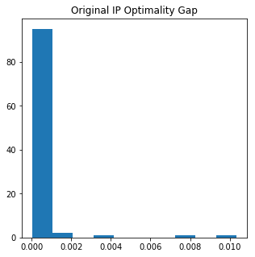

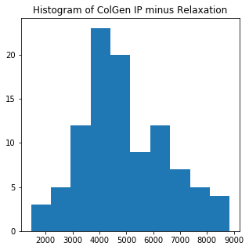

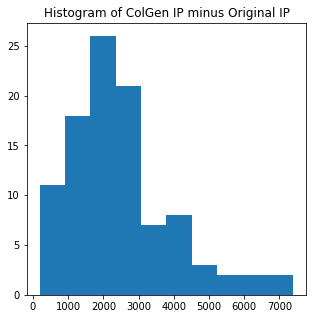

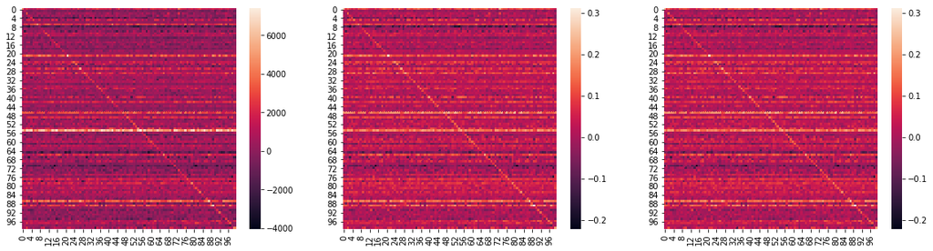

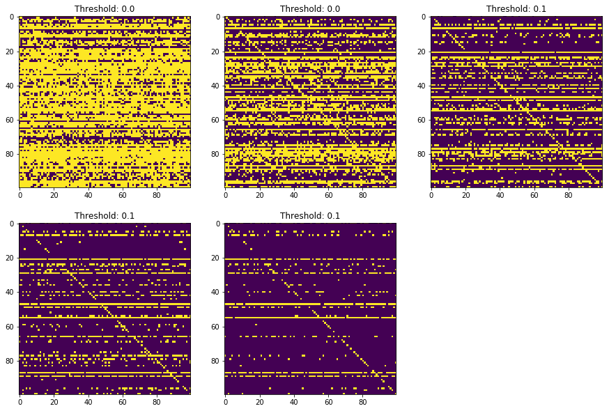

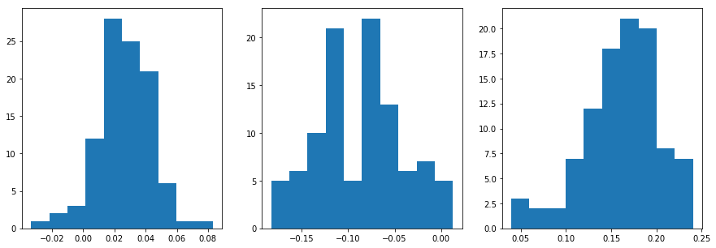

```python
n = 100
pickle_file = 'temprange_0_500.p'
with open(pickle_file, 'rb') as f:
    data = pickle.load(f)
    gaps = [data[i]['ip']['gap'] for i in range(n)]
    plt.figure(figsize=(5,5))
    plt.hist(gaps)
    plt.title('Original IP Optimality Gap')

pickle_file = 'debug100.p'
with open(pickle_file, 'rb') as f:
    data = pickle.load(f)
process(n, data)
```

```python
n = 50
pickle_file = 'debug100.p'
with open(pickle_file, 'rb') as f:
    data = pickle.load(f)

print(data.keys())
seeded_data = data['seeded']

for instance_idx in range(n):
    instance_data = seeded_data[instance_idx]
    print("Processing Instance %d ..." % instance_idx)
    print("- true ip obj: %.2f" % (data['original_ip'][instance_idx]))
    print("- baseline ip obj: %.2f" % (data['baseline'][instance_idx]))
    print("- column gen relax obj: %.2f" % (data['relax_col_gen'][instance_idx]))
    # ip diff is with respect to baseline, positive is good
    for i in range(n):
        combo_data = instance_data[i]
        n_trivial_routes = 0
        n_seeded_routes = 0
        n_cg_routes = 0
        for lambda_names in combo_data['lambda'].values():
            for lambda_name in lambda_names:
                if lambda_name in combo_data['lambda_names']['seeded']:
                    n_seeded_routes += 1
                elif lambda_name in combo_data['lambda_names']['trivial']:
                    n_trivial_routes += 1
                else:
                    n_cg_routes += 1
        print("    (%d,%d) -- rounds: %d, routes: (%d,%d,%d,%d), relax: %.2f, ip diff: %.2f, percent gap closed: %.2f"
              % (instance_idx, i,
                 combo_data['rounds'],
                 combo_data['n_routes'],n_trivial_routes, n_seeded_routes, n_cg_routes,
                 combo_data['relax_obj'],
                 data['baseline'][instance_idx] - combo_data['ip_obj'],
                 100*(data['baseline'][instance_idx] - combo_data['ip_obj'])/(data['baseline'][instance_idx] - data['original_ip'][instance_idx])))
    print("")
```

```
dict_keys(['original_ip', 'seeded', 'baseline', 'relax_col_gen', 'test_range'])
Processing Instance 0 ...
- true ip obj: 21418.16
- baseline ip obj: 25737.17
- column gen relax obj: 18157.91
    (0,0) -- rounds: 30, routes: (154,2,16,1), relax: 18072.44, ip diff: 4319.01, percent gap closed: 100.00
    (0,1) -- rounds: 30, routes: (154,3,1,15), relax: 18082.47, ip diff: 1468.95, percent gap closed: 34.01
    (0,2) -- rounds: 30, routes: (152,2,1,15), relax: 18069.09, ip diff: 2296.63, percent gap closed: 53.17
    (0,3) -- rounds: 30, routes: (155,2,2,14), relax: 18115.11, ip diff: 1489.15, percent gap closed: 34.48
    (0,4) -- rounds: 30, routes: (155,3,4,11), relax: 18101.79, ip diff: 697.04, percent gap closed: 16.14
    (0,5) -- rounds: 30, routes: (152,2,1,15), relax: 18107.51, ip diff: 1486.61, percent gap closed: 34.42
    (0,6) -- rounds: 30, routes: (151,3,1,14), relax: 18091.68, ip diff: 808.20, percent gap closed: 18.71
    (0,7) -- rounds: 30, routes: (159,3,2,14), relax: 18160.30, ip diff: 2048.20, percent gap closed: 47.42
    (0,8) -- rounds: 30, routes: (151,4,0,15), relax: 18132.61, ip diff: 1605.96, percent gap closed: 37.18
    (0,9) -- rounds: 30, routes: (151,3,1,15), relax: 18068.31, ip diff: 2043.14, percent gap closed: 47.31
    (0,10) -- rounds: 30, routes: (154,2,1,15), relax: 18094.44, ip diff: 2056.81, percent gap closed: 47.62
    (0,11) -- rounds: 30, routes: (157,3,1,15), relax: 18114.46, ip diff: 1575.66, percent gap closed: 36.48
    (0,12) -- rounds: 30, routes: (154,3,1,14), relax: 18073.44, ip diff: 1053.88, percent gap closed: 24.40
    (0,13) -- rounds: 30, routes: (159,3,1,14), relax: 18100.76, ip diff: 829.90, percent gap closed: 19.22
    (0,14) -- rounds: 30, routes: (155,4,0,15), relax: 18097.26, ip diff: 725.78, percent gap closed: 16.80
    (0,15) -- rounds: 30, routes: (153,1,0,17), relax: 18085.59, ip diff: 1856.06, percent gap closed: 42.97
    (0,16) -- rounds: 30, routes: (160,3,0,15), relax: 18080.96, ip diff: 949.52, percent gap closed: 21.98
    (0,17) -- rounds: 30, routes: (152,3,1,15), relax: 18135.82, ip diff: 1483.84, percent gap closed: 34.36
    (0,18) -- rounds: 30, routes: (151,3,1,14), relax: 18084.99, ip diff: 1914.40, percent gap closed: 44.32
    (0,19) -- rounds: 30, routes: (159,2,2,15), relax: 18088.98, ip diff: 2334.20, percent gap closed: 54.04
    (0,20) -- rounds: 30, routes: (149,3,1,14), relax: 18082.79, ip diff: 2033.50, percent gap closed: 47.08
    (0,21) -- rounds: 30, routes: (155,2,2,14), relax: 18076.83, ip diff: 1814.57, percent gap closed: 42.01
    (0,22) -- rounds: 30, routes: (150,3,1,14), relax: 18069.84, ip diff: 1854.21, percent gap closed: 42.93
    (0,23) -- rounds: 30, routes: (151,3,1,15), relax: 18066.93, ip diff: 438.60, percent gap closed: 10.16
    (0,24) -- rounds: 30, routes: (152,3,0,15), relax: 18074.66, ip diff: 2023.50, percent gap closed: 46.85
    (0,25) -- rounds: 30, routes: (154,4,2,13), relax: 18116.99, ip diff: 1208.29, percent gap closed: 27.98
    (0,26) -- rounds: 30, routes: (154,3,0,15), relax: 18092.87, ip diff: 2764.63, percent gap closed: 64.01
    (0,27) -- rounds: 30, routes: (161,3,1,14), relax: 18103.02, ip diff: 1611.11, percent gap closed: 37.30
    (0,28) -- rounds: 30, routes: (149,3,0,16), relax: 18101.12, ip diff: 1515.62, percent gap closed: 35.09
    (0,29) -- rounds: 30, routes: (152,4,1,14), relax: 18071.25, ip diff: 182.34, percent gap closed: 4.22
    (0,30) -- rounds: 30, routes: (168,2,1,15), relax: 18071.75, ip diff: 2234.44, percent gap closed: 51.74
    (0,31) -- rounds: 30, routes: (156,3,3,12), relax: 18075.90, ip diff: 2035.93, percent gap closed: 47.14
    (0,32) -- rounds: 30, routes: (154,3,1,14), relax: 18065.85, ip diff: 1654.83, percent gap closed: 38.31
    (0,33) -- rounds: 30, routes: (152,2,0,16), relax: 18076.48, ip diff: 2406.49, percent gap closed: 55.72
    (0,34) -- rounds: 30, routes: (154,2,2,14), relax: 18092.46, ip diff: 2033.04, percent gap closed: 47.07
```

[output cut: 2695 more lines]

```
    (49,35) -- rounds: 30, routes: (162,2,1,17), relax: 21866.10, ip diff: 1849.61, percent gap closed: 48.34
    (49,36) -- rounds: 30, routes: (156,3,0,17), relax: 21936.95, ip diff: 1321.96, percent gap closed: 34.55
    (49,37) -- rounds: 30, routes: (158,2,3,15), relax: 21906.74, ip diff: 2063.90, percent gap closed: 53.94
    (49,38) -- rounds: 30, routes: (155,2,0,18), relax: 21889.64, ip diff: 1082.52, percent gap closed: 28.29
    (49,39) -- rounds: 30, routes: (154,2,2,16), relax: 21874.93, ip diff: 1763.39, percent gap closed: 46.09
    (49,40) -- rounds: 30, routes: (155,2,1,17), relax: 21863.55, ip diff: 878.78, percent gap closed: 22.97
    (49,41) -- rounds: 30, routes: (154,3,2,15), relax: 21860.48, ip diff: 2513.53, percent gap closed: 65.69
    (49,42) -- rounds: 30, routes: (158,2,2,16), relax: 21866.74, ip diff: 1856.31, percent gap closed: 48.51
    (49,43) -- rounds: 30, routes: (156,3,2,15), relax: 21849.09, ip diff: 2331.83, percent gap closed: 60.94
    (49,44) -- rounds: 30, routes: (155,2,1,17), relax: 21876.64, ip diff: 2207.35, percent gap closed: 57.69
    (49,45) -- rounds: 30, routes: (157,1,2,16), relax: 21922.06, ip diff: 1682.99, percent gap closed: 43.98
    (49,46) -- rounds: 30, routes: (153,1,2,17), relax: 21861.61, ip diff: 1529.62, percent gap closed: 39.98
    (49,47) -- rounds: 30, routes: (153,3,2,15), relax: 21858.87, ip diff: 1976.56, percent gap closed: 51.66
    (49,48) -- rounds: 30, routes: (153,2,2,16), relax: 21862.13, ip diff: 871.54, percent gap closed: 22.78
    (49,49) -- rounds: 30, routes: (154,1,16,2), relax: 21846.79, ip diff: 3476.62, percent gap closed: 90.86
```

```python
import test_ml

test_option = 1

if test_option == 1:
    n_ports = 9
    n_vcs = 4
    n_periods = 30
    seed = 1
    n_instances = 1000

lp_dir = '.'
base_folder = '%s/ports%d_vcs%d_t%d_seed%d_n%d' % (lp_dir,
                                                   n_ports,
                                                   n_vcs,
                                                   n_periods,
                                                   seed,
                                                   n_instances)

cg_pickle_file = 'debug100.p'
with open(cg_pickle_file, 'rb') as f:
    cg_data = pickle.load(f)
```

```python
##cg_pickle_file = 'debug.p'
##with open(cg_pickle_file, 'rb') as f:
##    cg_data = pickle.load(f)

#output_data = {k:v[0:100] for k,v in cg_data.items()}
#output_data['seeded'] = [v[0:100] for v in output_data['seeded']]

#with open('debug100.p', 'wb') as f:
#    pickle.dump(output_data, f, protocol=pickle.HIGHEST_PROTOCOL)
```

```python
first_test_idx = 0
n_test_instances = 500
pickle_file = 'temprange_%d_%d.p' % (first_test_idx,
                                     first_test_idx + n_test_instances)
test_range = list(range(first_test_idx,
                        first_test_idx + n_test_instances))

with open(pickle_file, 'rb') as f:
    solution_data = pickle.load(f)

#test_ml.test_ml(base_folder, test_range, solution_data, cg_data)
```

```python
import features
import importlib
import metric_learn
import test_ml
import base
importlib.reload(test_ml)
importlib.reload(features)
importlib.reload(base)

def pos_neg_pairs(test_range, solution_data, cg_data,
                  threshold_type='lp',
                  threshold_yes=0.2, threshold_no=0.1):
    n_test = len(test_range)
    M = np.zeros((n_test,n_test))
    seeded_data = cg_data['seeded']
    lp_objs = cg_data['relax_col_gen']
    for i in range(n_test):
        instance_idx = test_range[i]
        instance_data = seeded_data[instance_idx]
        gap = cg_data['baseline'][instance_idx] - cg_data['original_ip'][instance_idx]
        ip_diffs = [cg_data['baseline'][instance_idx] - instance_data[test_range[j]]['ip_obj']
                    for j in range(n_test)]
        for j in range(n_test):
            if i == j:
                continue
            gap_closed = ip_diffs[j] / gap
            if threshold_type == 'percent':
                if gap_closed >= threshold_yes:
                    M[i,j] = 1
                elif gap_closed <= threshold_no and M[i,j] == 0:
                    M[i,j] = -1
            elif threshold_type == 'abs':
                ip_diff = ip_diffs[j]
                if ip_diff >= threshold_yes:
                    M[i,j] = 1
                elif ip_diff <= threshold_no and M[i,j] == 0:
                    M[i,j] = -1
            elif threshold_type == 'lp':
                ip_diff_normed = ip_diffs[j] / lp_objs[i]
                if ip_diff_normed >= threshold_yes:
                    M[i,j] = 1
                elif ip_diff_normed <= threshold_no and M[i,j] == 0:
                    M[i,j] = -1
            elif threshold_type == 'top':
                ip_diff_normed = ip_diffs[j] / lp_objs[i]
                if ip_diff_normed <= threshold_no and M[i,j] == 0:
                    M[i,j] = -1
            else:
                print("invalid threshold type")
                return
        if threshold_type == 'top':
            a = np.array(ip_diffs)
            row_indices = sorted(range(len(a)), key=lambda k: a[k], reverse=True)[1:1+threshold_yes]
            #print(a[row_indices])
            for j in row_indices:
                if M[i,j] > -1:
                    M[i,j] = 1

    A = []
    B = []
    C = []
    D = []
    for i in range(n_test):
        for j in range(i+1,n_test):
            if M[i,j] == 1 or M[j,i] == 1:
                A.append(i)
                B.append(j)
            elif M[i,j] == -1 and M[j,i] == -1:
                C.append(i)
                D.append(j)

    A = np.array(A).astype(int)
    B = np.array(B).astype(int)
    C = np.array(C).astype(int)
    D = np.array(D).astype(int)

    return A,B,C,D
```

```python
n = 100
first_test_idx = 0
n_test_instances = n

pickle_file = 'temprange_0_500.p'
test_range = list(range(first_test_idx, first_test_idx + n_test_instances))

with open(pickle_file, 'rb') as f:
    solution_data = pickle.load(f)

pickle_file_lp = 'temprange_0_100_lp.p'

with open(pickle_file_lp, 'rb') as f:
    lp_data = pickle.load(f)

output_data = {}
n_test = len(test_range)
instance_files = ['%s/instance_i%d_data.txt' % (base_folder, i)
                  for i in test_range]

cg_data_by_instance = [{k:v[i] for k,v in cg_data.items()}
                       for i in range(n_test)]

ipgap = [cg_data['baseline'][i] - cg_data['original_ip'][i]
         for i in range(n_test)]

feature_vectors = []

for i in range(n_test):
    instance_file = instance_files[i]
    mirp = generator.load(instance_file)
    mirp.build_graphs()
    f_vec = features.extract(mirp, cg_data_by_instance[i], lp_data[i])
    feature_vectors.append(f_vec)

X = np.array(feature_vectors)
```

```python
#print(X[1,:])
#print(X[2,:])

test_prod1 = list(itertools.product(['lp'],[0.025,0.05,0.075,0.1],[-0.03,-0.02,-0.01,0.0,0.01]))
test_prod2 = list(itertools.product(['top'],[5,10,15,20],[-0.03,-0.02,-0.01,0.0,0.01]))
test_prod3 = list(itertools.product(['top'],[5,10,15,20],[-0.05,-0.04]))
test_prod = test_prod1 + test_prod2
print(test_prod3)
print(len(test_prod))
params_list =  test_prod3
```

```
[('top', 5, -0.05), ('top', 5, -0.04), ('top', 10, -0.05), ('top', 10, -0.04), ('top', 15, -0.05), ('top', 15, -0.04), ('top', 20, -0.05), ('top', 20, -0.04)]
40
```

```python
#A,B,C,D = pos_neg_pairs(test_range, solution_data, cg_data)

#params = itertools.product()

params_list = [#('abs',500,-200)]
               ('top', 15, -0.06),('top', 15, -0.05),('top', 15, -0.04),
               #('percent', 0.2, -0.1),
               #('lp', 0.025, -0.025)
               ]
params_list =  test_prod

#params_list = list(itertools.product(['percent'],[0.1,0.15,0.2,0.25,0.3],[-0.2,-0.15,-0.1,-0.05,0,0.05,0.1]))


mmc_list = []
X_fitted_list = []
for params in params_list:
    print(params)
    A,B,C,D = pos_neg_pairs(test_range, solution_data, cg_data,
                            threshold_type=params[0],
                            threshold_yes=params[1],
                            threshold_no=params[2])
    #print(A)
    #print(B)
    #print(C)
    #print(D)

    mmc = metric_learn.ITML(verbose=True)
    mmc.fit(X,(A,B,C,D))
    mmc_list.append(mmc)
    X_fitted_list.append(mmc.transform(X))

#M = mmc.metric()
#w,v = np.linalg.eig(M)
#X_fitted = mmc.transform(X)
#M = mmc.metric()
```

[output not shown]

[output cut: 405 more lines]

[output not shown]

```python
from sklearn.metrics.pairwise import euclidean_distances

n = 100
matrix = np.zeros((n,n))
for i,j in itertools.product(range(n), range(n)):
    matrix[i,j] = cg_data['baseline'][i] - cg_data['seeded'][i][j]['ip_obj']

#cov = metric_learn.Covariance()
#cov.fit(X)
#('abs',2000,-1000),
#('top', 10, -0.1),
#('percent', 0.2, -0.1),
#('percent', 0.3, -0.1)
#('abs',500,-200)
#('percent', 0.2, -0.0)
#itertools.product(['percent'],[0.1,0.15,0.2,0.25,0.3],[-0.2,-0.15,-0.1,-0.05,0,0.05,0.1])
#('percent', 0.25, -0.0) new features
#('percent', 0.2, 0.1) new features
#('percent', 0.2, 0.1) newer features
#saved_X_fitted_list += X_fitted_list

#import pickle

#with open("x_arrays.p", 'wb') as f:
#    pickle.dump(output_data, f, protocol=pickle.HIGHEST_PROTOCOL)

with open("x_arrays.p", 'rb') as f:
    X_fitted_list = pickle.load(f)

#cov_distance = euclidean_distances(cov.transform(X))
```

```python
def bottom_k_indices(row, k, reverse):
    row_indices = sorted(range(len(row)), key=lambda i: row[i], reverse=reverse)[1:1+k]
    return row_indices

def random_sample_top_k_mean(row, k):
    x = sorted(row, reverse=True)
    x = x[1:]
    #print(x)

    total = 0

    n = len(x)
    factor = (k/n)
    for i in range(n-k+1):
        total += factor * x[i]
        #print(total)
        if (i < n-k):
            factor *= (n-k-i)/(n-(i+1))

    #print(total)
    return total

params_list =  test_prod
lp_objs = cg_data['relax_col_gen']


X_idx = 0
for X_fitted in X_fitted_list:
    #X_fitted = mmc.transform(X)
    #print(X_fitted[0:5,0:5])
    #print(X[0:5,0:5])
    fitted_distance = euclidean_distances(X_fitted)
    original_distance = euclidean_distances(X)

    #print(fitted_distance[0:5,0:5])
    #print(original_distance[0:5,0:5])

    diffs = []
    gaps = []
    improvements_best = []
    improvements_euc = []
    improvements_cov = []
    improvements_ml = []
    improvements_rng = []

    for test_idx in range(n):
        #print("Instance %d" % test_idx)
        a = matrix[test_idx,0:n]
        a_indices = bottom_k_indices(a, 5, True)
        b_indices = bottom_k_indices(fitted_distance[test_idx,0:n], 5, False)
        c_indices = bottom_k_indices(original_distance[test_idx,0:n], 5, False)

        #print(a)
        #print(fitted_distance[test_idx,0:n])
        #print(original_distance[test_idx,0:n])

        #print(c_indices)
        #print(b_indices)
        #d_indices = bottom_k_indices(cov_distance[test_idx,0:n], n, 5, False)

        text = "[%.1f %.1f] [%.1f %.1f] [%.1f %.1f]" % (max(a[a_indices]),min(a[a_indices]),
                                                  max(a[b_indices]),min(a[b_indices]),
                                                  max(a[c_indices]),min(a[c_indices]))
        #print(text)
        gap = max(a)
        improve_best = max(a[a_indices])
        improve_ml = max(a[b_indices])
        improve_euc = max(a[c_indices])
        improve_rng = random_sample_top_k_mean(a,5)
        #improve_cov = max(a[d_indices])

        improvements_best.append(improve_best)
        improvements_euc.append(improve_euc)
        improvements_ml.append(improve_ml)
        improvements_rng.append(improve_rng)
        #improvements_cov.append(improve_cov)

        gaps.append(gap)

        #print("%.1f,%.1f" % (diff, gap))

    ml_vs_euc = [improvements_ml[i] - improvements_euc[i] for i in range(n)]
    #ml_vs_cov = [improvements_ml[i] - improvements_cov[i] for i in range(n)]

    print(params_list[X_idx])

    print("Overall best percentage: %.3f" % (100*sum(improvements_best[i]/lp_objs[i] for i in range(n))/n))
    print("Overall best absolute: %.1f" % (sum(improvements_best)/n))
    print("Overall euc percentage: %.3f" % (100*sum(improvements_euc[i]/lp_objs[i] for i in range(n))/n))
    print("Overall euc absolute: %.1f" % (sum(improvements_euc)/n))
    print("Overall rng percentage: %.3f" % (100*sum(improvements_rng[i]/lp_objs[i] for i in range(n))/n))
    print("Overall rng absolute: %.1f" % (sum(improvements_rng)/n))
    print("Overall ml percentage: %.3f" % (100*sum(improvements_ml[i]/lp_objs[i] for i in range(n))/n))
    print("Overall ml absolute: %.1f" % (sum(improvements_ml)/n))

    print("Overall Improvement euc percentage: %.3f" % (100*sum(ml_vs_euc[i]/lp_objs[i] for i in range(n))/n))
    print("Overall Improvement euc absolute: %.3f" % (sum(ml_vs_euc)/n))
    #print("Overall Improvement cov percentage: %.1f" % (100*sum(ml_vs_cov[i]/gaps[i] for i in range(n))/n))
    #print("Overall Improvement cov absolute: %.1f" % (sum(ml_vs_cov)/n))
    print("Overall Gap absolute: %.1f" % (sum(gaps)/n))

    X_idx += 1
```

```
('lp', 0.025, -0.03)
Overall best percentage: 8.283
Overall best absolute: 1776.5
Overall euc percentage: 5.606
Overall euc absolute: 1220.8
Overall rng percentage: 5.482
Overall rng absolute: 1199.7
Overall ml percentage: 5.909
Overall ml absolute: 1282.8
Overall Improvement euc percentage: 0.302
Overall Improvement euc absolute: 61.942
Overall Gap absolute: 2449.3
('lp', 0.025, -0.02)
Overall best percentage: 8.283
Overall best absolute: 1776.5
Overall euc percentage: 5.606
Overall euc absolute: 1220.8
Overall rng percentage: 5.482
Overall rng absolute: 1199.7
Overall ml percentage: 5.681
Overall ml absolute: 1239.9
Overall Improvement euc percentage: 0.075
Overall Improvement euc absolute: 19.023
Overall Gap absolute: 2449.3
('lp', 0.025, -0.01)
Overall best percentage: 8.283
Overall best absolute: 1776.5
Overall euc percentage: 5.606
Overall euc absolute: 1220.8
Overall rng percentage: 5.482
Overall rng absolute: 1199.7
Overall ml percentage: 5.611
Overall ml absolute: 1223.6
Overall Improvement euc percentage: 0.005
Overall Improvement euc absolute: 2.770
Overall Gap absolute: 2449.3
('lp', 0.025, 0.0)
Overall best percentage: 8.283
Overall best absolute: 1776.5
Overall euc percentage: 5.606
```

[output cut: 425 more lines]

```
Overall Improvement euc percentage: 0.183
Overall Improvement euc absolute: 41.561
Overall Gap absolute: 2449.3
('top', 20, 0.01)
Overall best percentage: 8.283
Overall best absolute: 1776.5
Overall euc percentage: 5.606
Overall euc absolute: 1220.8
Overall rng percentage: 5.482
Overall rng absolute: 1199.7
Overall ml percentage: 5.802
Overall ml absolute: 1268.3
Overall Improvement euc percentage: 0.196
Overall Improvement euc absolute: 47.421
Overall Gap absolute: 2449.3
```

```
[65 71 26  9 10  4 74 67  1 53 91 58 80 92  2 93 16 22 41 60 39 38 73 52
 72 31 85 79 75 43 44 11 20 95 51 30 42 99 78 15 83 19 21 66 62 12 69 35
 86 27 25 81 87 32 46 56 94  3  7 37 17 24 40 63 59 88 76 90 54 64 82  0
 77 48 29 23 98 33 96 36 84 49 47 45 28 55 89 50 97  5 68  6 14 13 70 61
 34 18 57  8]
```

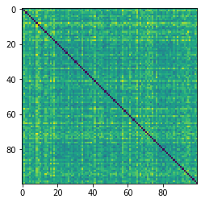

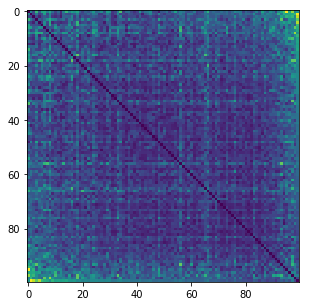

```python
M = instance_distance
plt.imshow(M)
M = np.power(M,3)
order = get_order(M)
print(order)
plt.figure(figsize=(5,5))
M = M[:,order]
M = M[order,:]
plt.imshow(M)
```

```python
"""
DEBUGGING ONLY
"""

from metric_learn import ITML_Supervised
from sklearn.datasets import load_iris

iris_data = load_iris()
X = iris_data['data']
Y = iris_data['target']

itml = ITML_Supervised(num_constraints=200)
itml.fit(X, Y)

print(X)
print(itml.transform(X))
print(itml.metric())
```

[output not shown]

[output cut: 249 more lines]

```
 [-0.34111236 -2.19189149  1.56910655  1.66294046]
 [-0.69591848 -2.58557978  1.63440152  1.90050338]
 [-0.25670532 -2.3206984   1.49216534  1.82131574]
 [-0.67029078 -2.10998118  1.4792415   1.50456518]
 [-0.77404979 -2.50945218  1.7145737   1.82131574]
 [-0.80807158 -2.61111356  1.66543353  1.97969102]
 [-0.41874491 -2.40952944  1.51996638  1.82131574]
 [-0.32392856 -2.19511499  1.45144046  1.50456518]
 [-0.3999047  -2.07752667  1.51027351  1.58375282]
 [-0.83398182 -2.23926182  1.57556847  1.82131574]
 [-0.58934498 -1.82534873  1.47601054  1.42537753]]
[[ 0.30799732 -0.03298422 -0.31626891 -0.24018436]
 [-0.03298422  0.33979649 -0.14498182 -0.61602042]
 [-0.31626891 -0.14498182  0.49718002  0.59694654]
 [-0.24018436 -0.61602042  0.59694654  2.04014574]]
```

# Summary 11/21/2018

## Learning Experiments

#### Preliminary stuff:

- For every instance $i$:
  - First run the column heuristic i.e. compute $CG(i,\emptyset)$.
  - Then for each instance, take it's optimal columns and share with $i$. i.e. compute $CG(i,j)$.
  - Populate "improvement matrices" $$M_\text{abs}(i,j) \gets CG(i,j) - CG(i,\emptyset)$$ and $$M_\text{pct}(i,j) \gets \frac{CG(i,j) - CG(i,\emptyset)}{IP(i)}$$.
- From $M$ matrices, determine *similar/dissimiliar* pairs for feeding in metric learning algorithms. Options below:
  1. Set $u,l$ such that $M_\text{abs}(i,j) > u$ means $i,j$ are similar, $M_\text{abs}(i,j) < l$ are different.
  2. Same, but with $M_\text{pct}$.
  3. Pick $k,l$. For each $i$, set the top $k$ M(i,j) to be similar, and $M(i,j) < l$ to different. If both are true for some $i,j$, then different takes precedence.
- Resolving similarity/dissimilarity conflicts
  - Since $M$ matrices are not symmetric but similarity/dissimilarity is a symmetric concept, we need a way to resolve this
  - Current heuristic: If one of $(i,j), (j,i)$ is "similar", then $(i,j)$ is similar. If neither are similar and one of them is "dissimilar", then dissimilar.

#### Metric Learning stuff:

- Took 100 instances.
- Goal, learn a matrix $P = LL^T$ to transform features $X \rightarrow L^T X$
- Features used for Metric Learning
  - ports: rates/inventory/capacities
  - vessel classes: number of vessels, number fixed starting locations
  - ports x vessel classes: number fixed starting
  - column generation: $CG(i,\emptyset)$ minus LP relaxation. (maybe divide by LP relaxation)
  - (maybe make things relative?)
- Learning Methods tested
  - Classic MMC model (Mahalanobis Metric learning for Clustering, first metric learning method) doesn't seem to work.
  - Tried ITML instead (Information Theoretic Metric Learning).
- Methodology
  - Goal: An approximation of real work-flow that's quick to run
  - For each instance $i$, find 5 closest instances according to computed metric.
  - Take the best $CG(i,j)$ out of these five
  - (what if we take columns from all 5?)
- Observations
  - best results obtained
    - relative measure for choosing similarities with thresholds of 20%, 10%
    - Compared this result against standard Euclidean metric

      ```
      Overall best percentage: 70.6
      Overall best absolute: 1776.5
      Overall euc percentage: 38.8
      Overall euc absolute: 1177.5
      Overall ml percentage: 44.7
      Overall ml absolute: 1258.7
      Overall Improvement euc percentage: 5.9
      Overall Improvement euc absolute: 81.2
      Overall Gap absolute: 2449.3
      ```